# FT8 Contest April 2020

Rick Gilmore K3ROG

2020-04-14 14:14:30

# Purpose

This document summarizes the results from the 2020-04-11 to 2020-04-12 FT8 contest that N3LI, W3SWL, and K3ROG participated in from their home stations. We shared use of the W3YA callsign.

# Log processing

We exported ADIF format logs from WSJT-X. The logs are available on Google Drive.

## Authenticate to Google Drive

We use the `googledrive` (https://googledrive.tidyverse.org/) package. Running the following command will launch a browser where you must authenticate to Google using the credentials for the account you use to access these files.

We all uploaded ADIF files with the same general pattern: `W3YA_K3ROG_all.adi`, so we can search for that pattern.

```r
if (!is.null(dim(list.files(".", pattern = "\\.adf$")))) {
  log_files <- googledrive::drive_find(pattern = "_all.adi")
}
```

## Downloading ADIF logs

We extract the file information by detecting the callsign in the `name` field.

```r
if (!is.null(dim(list.files(".", pattern = "\\.adf$")))) {
  k3rog_log <- log_files %>%
    dplyr::filter(., stringr::str_detect(name, "K3ROG"))

  w3swl_log <- log_files %>%
    dplyr::filter(., stringr::str_detect(name, "W3SWL"))

  n3li_log <- log_files %>%
    dplyr::filter(., stringr::str_detect(name, "N3LI"))
}
```

Now, we can download each of the logs.

```r
if (!is.null(dim(list.files(".", pattern = "\\.adf$")))) {
  googledrive::drive_download(k3rog_log, overwrite = TRUE)
  googledrive::drive_download(w3swl_log, overwrite = TRUE)
  googledrive::drive_download(n3li_log, overwrite = TRUE)
}
```

I tried to specify a particular output directory using the `path` option, but got the following type of error:

`Error in curl::curl_fetch_disk(url, x$path, handle = handle) : Failed to open file adif/test.txt.`

## Importing

### Loading helper functions

```r
read_adif <- function(fn) {
  if (!file.exists(fn)) stop("file '", fn, "' not found.")
  readtext(file = fn, )
}

read_adif <- function(fn) {
  if (!file.exists(fn)) stop("file '", fn, "' not found.")
  readtext(file = fn, )
}

extract_qsos_from_adif <- function(adif) {
  unlist(stringr::str_match_all(adif, "<.*<eor>\n"))
}

extract_qso_fields <- function(qso_line) {
  if (!is.character(qso_line)) stop("'qso_line' must be character.")
  field_label_value_regex <- "<([a-z]+[_a-z]*):([0-9]+)>([a-zA-Z0-9/\\.]+)"
  df <- as.data.frame(stringr::str_match_all(qso_line, field_label_value_regex))

  if (is.null(df)) {
    stop("No fields matched.")
  }

  if (dim(df)[2] != 4) {
    stop("Extracted data frame does not have expected number of columns.")
  }
  df[, c(2,4)]
}

make_qso_wide <- function(qso_df) {
  tidyr::pivot_wider(qso_df, names_from = X2, values_from = X4)
}

make_wide_qso_df <- function(qso_line) {
  df <- extract_qso_fields(qso_line)
  make_qso_wide(df)
}

make_qsos_df <- function(adif) {
  qsos <- extract_qsos_from_adif(adif)
  purrr::map_df(qsos, make_wide_qso_df)
}

convert_db_to_rst <- function(rpt) {
  if (is.na(rpt) || rpt > 500) {
    as.character(rpt)
  } else {
    noise_floor <- -26
    db_to_s_units <- 6
    paste0("5", round((rpt - noise_floor)/6), "9")
  }
}
```

### Loading data files

```r
if (!is.null(dim(list.files(".", pattern = "\\.adf$")))) {
  k3rog_adif <- read_adif(k3rog_log$name)
  w3swl_adif <- read_adif(w3swl_log$name)
  n3li_adif <- read_adif(n3li_log$name)
} else {
  adif_fl <- list.files(".", pattern = "\\.adi$")
  k3rog_adif <- read_adif(adif_fl[stringr::str_detect(adif_fl, "K3ROG")])
  w3swl_adif <- read_adif(adif_fl[stringr::str_detect(adif_fl, "W3SWL")])
  n3li_adif <- read_adif(adif_fl[stringr::str_detect(adif_fl, "N3LI")])
}
```

### Convert to data frames

```r
k3rog_df <- make_qsos_df(k3rog_adif)
w3swl_df <- make_qsos_df(w3swl_adif)
n3li_df <- make_qsos_df(n3li_adif)
```

## Cleaning

```r
w3swl_df <- dplyr::select(w3swl_df,-`tx_pwr`)

n3li_df <- dplyr::select(n3li_df,-`tx_pwr`)
n3li_df$operator <- "N3LI"
n3li_df <- dplyr::select(
  n3li_df,
  qso_date,
  time_on,
  qso_date_off,
  time_off,
  band,
  freq,
  station_callsign,
  my_gridsquare,
  call,
  rst_sent,
  rst_rcvd,
  srx,
  state,
  operator
)
# Convert signal reports
n3li_df <-
  dplyr::mutate(n3li_df,
                rst_sent = convert_db_to_rst(as.numeric(rst_sent)),
                rst_rcvd = convert_db_to_rst(as.numeric(rst_rcvd)))
```

Create combined data frame and filter based on key fields.

```r
all_df <- dplyr::full_join(k3rog_df, w3swl_df)
all_df <- dplyr::full_join(all_df, n3li_df)
all_df <- all_df %>%
  dplyr::arrange(., call, band, qso_date, time_on, band) %>%
  dplyr::filter(., stringr::str_detect(qso_date, '2020041[12]'))
```

Address dupes.

```r
dupes <- all_df %>%
  dplyr::group_by(., call, band) %>%
  dplyr::summarize(., n_qsos_in_band = n()) %>%
  dplyr::mutate(., dup_qsos = n_qsos_in_band - 1) %>%
  dplyr::select(., call, band, n_qsos_in_band, dup_qsos)

all_df <- all_df %>%
  dplyr::group_by(., call, band) %>%
  dplyr::mutate(., n_qso_w_call = dplyr::row_number())

#all_df <- left_join(all_df, dupes, by = c("call", "band"))

# Total QSOs without filtering dupes
tot_qsos <- dim(all_df)[1]

# Filter dupes
all_df <- all_df %>%
  dplyr::filter(., n_qso_w_call == 1)

dup_qsos <- sum(dupes$dup_qsos)
```

Recode sent signals as numbers and dates and times as a date/time stamp.

```r
convert_to_date <- function(d) {
  paste0(substr(d, 1, 4), "-", substr(d, 5, 6), "-", substr(d, 7, 8))
}

convert_to_time <- function(t) {
  tp <- str_pad(t, 6, pad = "0")
  paste0(substr(t, 1, 2), ":", substr(t, 3, 4), ":", substr(t, 5, 6))
}

all_df <- all_df %>%
  dplyr::mutate(.,
                rst_rcvd = as.numeric(rst_rcvd),
                rst_sent = as.numeric(rst_sent)) %>%
  dplyr::mutate(.,
                date_time = lubridate::as_datetime(paste0(
                  convert_to_date(qso_date), " ", convert_to_time(time_on)
                )))
```

# Analysis and visualization

## QSOs by band and operator

```r
xtabs(formula = ~ band + operator, data = all_df) %>%
  knitr::kable()
```

|  | K3ROG | N3LI | W3SWL |
| --- | --- | --- | --- |
| 15m | 6 | 1 | 8 |
| 20m | 33 | 32 | 52 |
| 40m | 28 | 37 | 24 |
| 80m | 8 | 43 | 2 |

## Unique stations and locations

### States and provinces

```r
states_df <- all_df %>%
  dplyr::filter(., !is.na(state))
xtabs(formula = ~ state + band, data = states_df) %>%
  knitr::kable()
```

|  | 20m | 40m | 80m |
| --- | --- | --- | --- |
| AB | 2 | 0 | 0 |
| AL | 0 | 1 | 0 |
| CA | 0 | 2 | 1 |
| CO | 3 | 1 | 0 |
| DE | 0 | 1 | 0 |
| FL | 5 | 10 | 3 |
| GA | 0 | 1 | 1 |
| IA | 0 | 1 | 0 |
| IL | 0 | 2 | 1 |
| IN | 0 | 1 | 1 |
| LA | 1 | 0 | 2 |
| MA | 0 | 2 | 3 |
| MD | 0 | 1 | 1 |
| MI | 0 | 1 | 2 |
| MN | 0 | 0 | 1 |
| MO | 0 | 1 | 0 |
| MS | 1 | 0 | 0 |
| MT | 1 | 0 | 0 |
| NC | 0 | 3 | 0 |
| NF | 1 | 0 | 0 |
| NH | 0 | 1 | 1 |
| NJ | 0 | 0 | 2 |
| NM | 1 | 0 | 0 |
| NS | 0 | 1 | 0 |
| OH | 0 | 3 | 5 |
| ON | 0 | 2 | 2 |
| OR | 0 | 1 | 0 |
| PA | 0 | 1 | 2 |
| QC | 0 | 1 | 1 |
| SC | 0 | 4 | 1 |
| TN | 0 | 6 | 1 |
| TX | 13 | 8 | 4 |
| WA | 4 | 1 | 1 |
| WI | 0 | 4 | 0 |

### Grid squares

```r
grids_df <- all_df %>%
  dplyr::filter(., !is.na(gridsquare))
xtabs(formula = ~ gridsquare + band, data = grids_df) %>%
  knitr::kable()
```

|  | 15m | 20m | 40m | 80m |
| --- | --- | --- | --- | --- |
| CN85 | 0 | 0 | 1 | 0 |
| CN87 | 0 | 1 | 1 | 0 |
| DL95 | 0 | 1 | 0 | 0 |
| DM59 | 0 | 1 | 0 | 0 |
| DM61 | 0 | 1 | 0 | 0 |
| DN07 | 0 | 1 | 0 | 0 |
| DO20 | 0 | 1 | 0 | 0 |
| EL09 | 0 | 2 | 0 | 0 |
| EL29 | 0 | 1 | 1 | 0 |
| EL82 | 0 | 3 | 1 | 0 |
| EL83 | 1 | 1 | 1 | 0 |
| EL96 | 0 | 0 | 1 | 0 |
| EL98 | 0 | 2 | 3 | 1 |
| EM10 | 0 | 1 | 0 | 0 |
| EM12 | 0 | 2 | 1 | 0 |
| EM13 | 0 | 2 | 2 | 0 |
| EM29 | 0 | 0 | 1 | 0 |
| EM40 | 0 | 1 | 0 | 0 |
| EM51 | 0 | 1 | 0 | 0 |
| EM79 | 0 | 0 | 0 | 1 |
| EM84 | 0 | 0 | 2 | 0 |
| EM86 | 0 | 0 | 1 | 0 |
| EM90 | 0 | 0 | 2 | 0 |
| EM95 | 0 | 0 | 2 | 0 |
| EN41 | 0 | 0 | 1 | 0 |
| EN51 | 0 | 0 | 1 | 0 |
| EN53 | 0 | 0 | 1 | 0 |
| EN61 | 0 | 0 | 0 | 1 |
| EN64 | 0 | 0 | 1 | 0 |
| EN66 | 0 | 0 | 1 | 0 |

[output cut: 53 more lines]

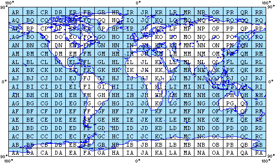

```r
knitr::include_graphics("https://qrznow.com/wp-content/uploads/2015/09/QTH_locator.gif")
```

## Signal reports

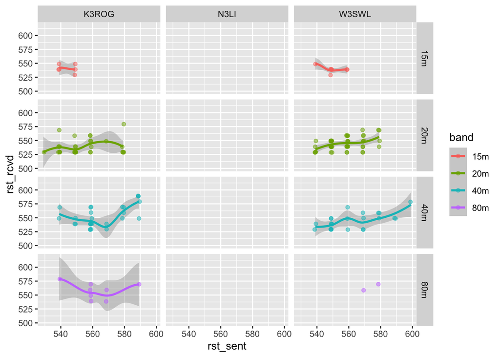

```r
all_df %>% ggplot(.) +
  aes(x = rst_sent, y = rst_rcvd, color = band) +
  geom_smooth() +
  geom_point(position = position_jitter(w = 0.55, h=0.5), alpha = .5) +
  facet_grid(band ~ operator)
```

### Received

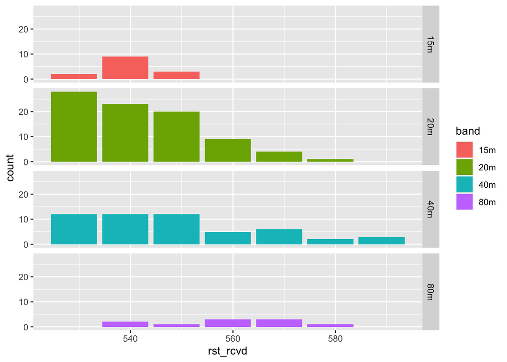

```r
all_df %>% ggplot(.) +
  aes(x = rst_rcvd, fill = band) +
  geom_bar() +
  facet_grid(band ~ .)
```

### Sent

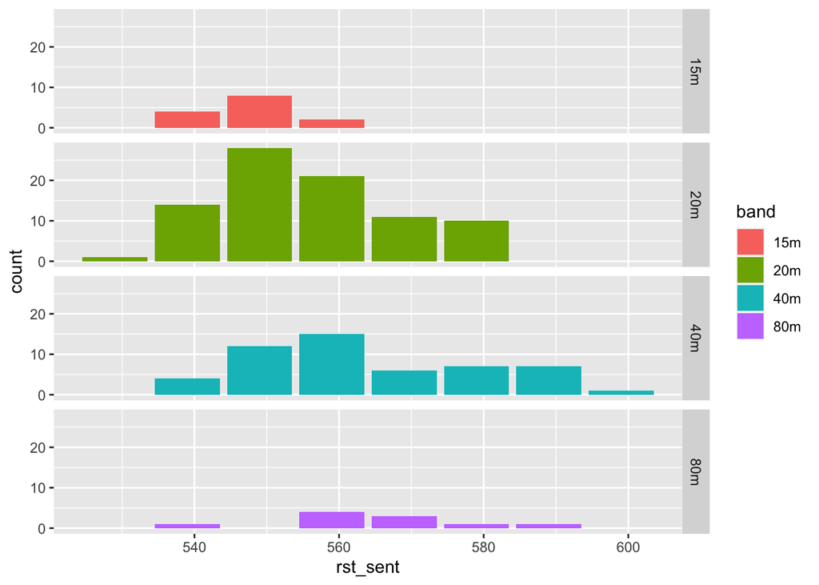

```r
all_df %>% ggplot(.) +
  aes(x = rst_sent, fill = band) +
  geom_bar() +
  facet_grid(band ~ .)
```

## Time

```r
all_df <- all_df %>%
  dplyr::arrange(., date_time) %>%
  dplyr::group_by(., band) %>%
  dplyr::mutate(., cum_qso_cnt = dplyr::row_number()) %>%
  ungroup()
```

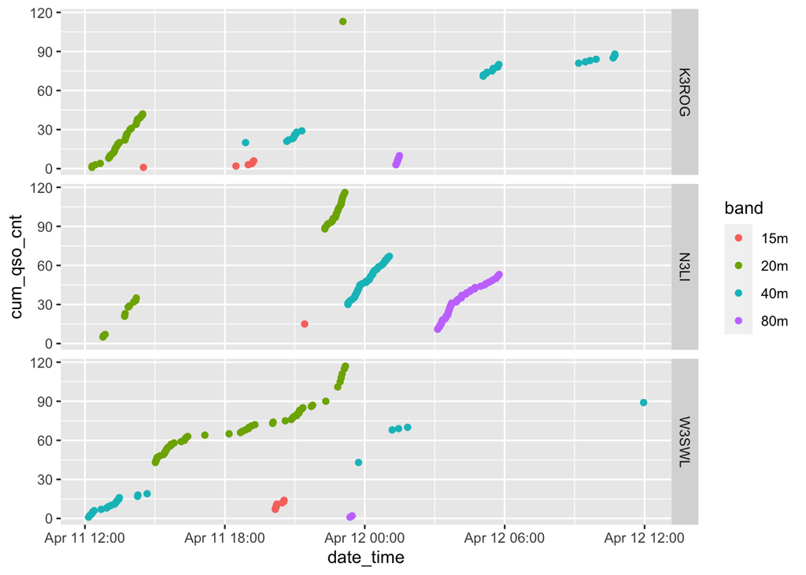

```r
all_df %>% ggplot(.) +
  aes(date_time, cum_qso_cnt, color = band) +
  geom_point() +
  facet_grid(operator ~ .)
```

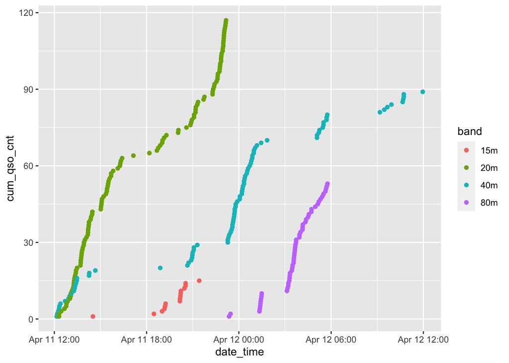

```r
all_df %>% ggplot(.) +
  aes(date_time, cum_qso_cnt, color = band) +
  geom_point()
```